# Crow Fault Bars v2

Justin Mann

2025-01-06

```r
palette.colors(palette = "Tableau 10")
```

```
##  [1] "#4E79A7" "#F28E2B" "#E15759" "#76B7B2" "#59A14F" "#EDC948" "#B07AA1"
##  [8] "#FF9DA7" "#9C755F" "#BAB0AC"
```

```r
fb.df <- read.csv("FaultBarMaster_15Nov24.csv", h=T)
fb.df$ID <- as.factor(fb.df$ID)
fb.df$Habitat <- as.factor(fb.df$Habitat)
n_occur <- data.frame(table(fb.df$ID))
n_occur[n_occur$Freq > 1,]#no repeat IDs
```

```
## [1] Var1 Freq
## <0 rows> (or 0-length row.names)
```

### Total fault bars by feather type model

```r
tot.type.mdl <- glmmTMB(data = fb.df, TotalBars ~ Type, family = "poisson")
summary(tot.type.mdl)
```

```
##  Family: poisson  ( log )
## Formula:          TotalBars ~ Type
## Data: fb.df
##
##      AIC      BIC   logLik deviance df.resid
##   1407.1   1416.6   -700.5   1401.1      176
##
##
## Conditional model:
##               Estimate Std. Error z value Pr(>|z|)
## (Intercept)    0.85693    0.08482  10.103  < 2e-16 ***
## Typesecondary  0.45714    0.10770   4.245 2.19e-05 ***
## Typetail       1.20541    0.09669  12.466  < 2e-16 ***
## ---
## Signif. codes:  0 '***' 0.001 '**' 0.01 '*' 0.05 '.' 0.1 ' ' 1
```

### Zero inflation test for tot.type.mdl

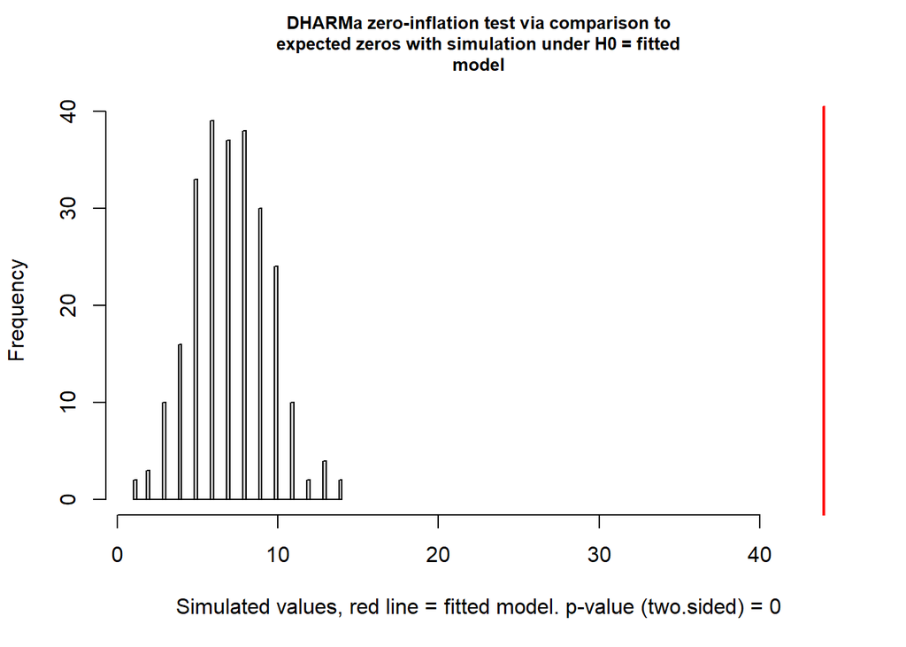

```
##
##  DHARMa zero-inflation test via comparison to expected zeros with
##  simulation under H0 = fitted model
##
## data:  simulationOutput
## ratioObsSim = 6.1521, p-value < 2.2e-16
## alternative hypothesis: two.sided
```

```r
tot.type.res.sim <- simulateResiduals(tot.type.mdl)
testZeroInflation(tot.type.res.sim)
```

### Overdispersion test for tot.type.mdl

```r
testOverdispersion(tot.type.res.sim)
```

```
## testOverdispersion is deprecated, switch your code to using the testDispersion function
```

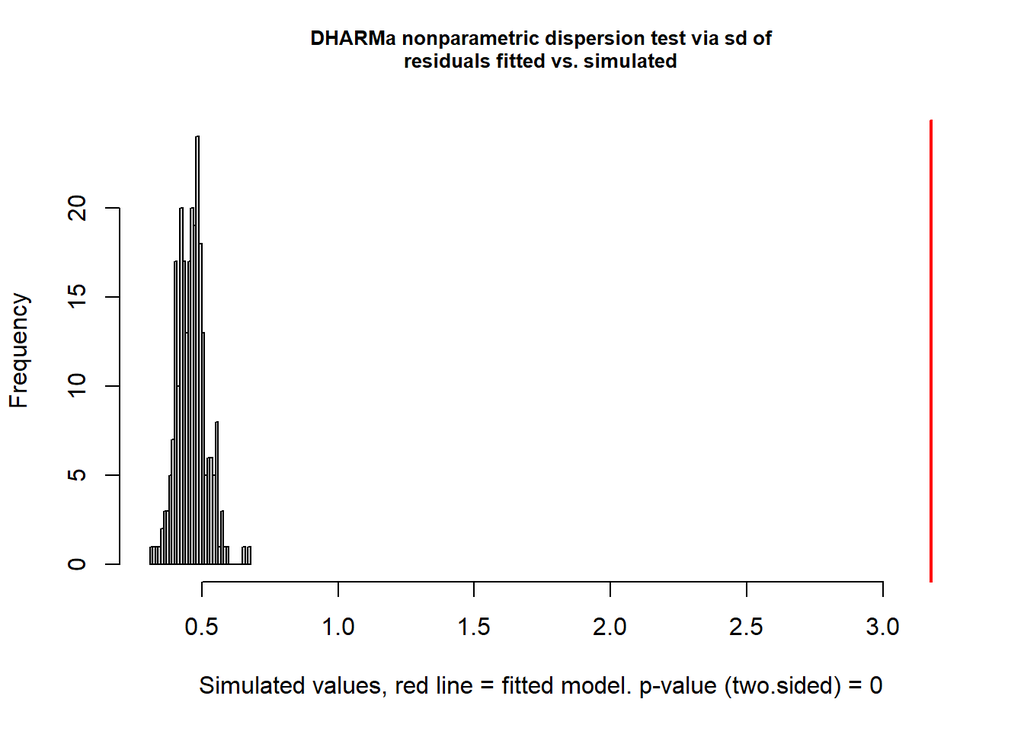

```
##
##  DHARMa nonparametric dispersion test via sd of residuals fitted vs.
##  simulated
##
## data:  simulationOutput
## dispersion = 6.8594, p-value < 2.2e-16
## alternative hypothesis: two.sided
```

### ZIP tot.type.mdl

```r
tot.type.ZIP.mdl <- glmmTMB(data = fb.df, TotalBars ~ Type, ziformula = ~1, family = "poisson")
```

### tot.type.mdl AIC comparison

```r
tot.type.NB1.mdl <- update(tot.type.ZIP.mdl, family = nbinom1)
tot.type.NB2.mdl <- update(tot.type.ZIP.mdl, family = nbinom2)
AICtab(tot.type.mdl,tot.type.ZIP.mdl,tot.type.NB1.mdl,tot.type.NB2.mdl)
```

```
##                  dAIC  df
## tot.type.NB2.mdl   0.0 5
## tot.type.NB1.mdl   0.6 5
## tot.type.ZIP.mdl 332.1 4
## tot.type.mdl     491.9 3
```

### tot.type best fit model

```r
summary(tot.type.NB2.mdl)
```

```
##  Family: nbinom2  ( log )
## Formula:          TotalBars ~ Type
## Zero inflation:             ~1
## Data: fb.df
##
##      AIC      BIC   logLik deviance df.resid
##    915.1    931.1   -452.6    905.1      174
##
##
## Dispersion parameter for nbinom2 family (): 0.819
##
## Conditional model:
##               Estimate Std. Error z value Pr(>|z|)
## (Intercept)     0.8569     0.1670   5.132 2.87e-07 ***
## Typesecondary   0.4571     0.2287   1.999   0.0456 *
## Typetail        1.2054     0.2252   5.352 8.70e-08 ***
## ---
## Signif. codes:  0 '***' 0.001 '**' 0.01 '*' 0.05 '.' 0.1 ' ' 1
##
## Zero-inflation model:
##             Estimate Std. Error z value Pr(>|z|)
## (Intercept)   -19.29    5001.40  -0.004    0.997
```

### Number of fault bars (>0) per feather type

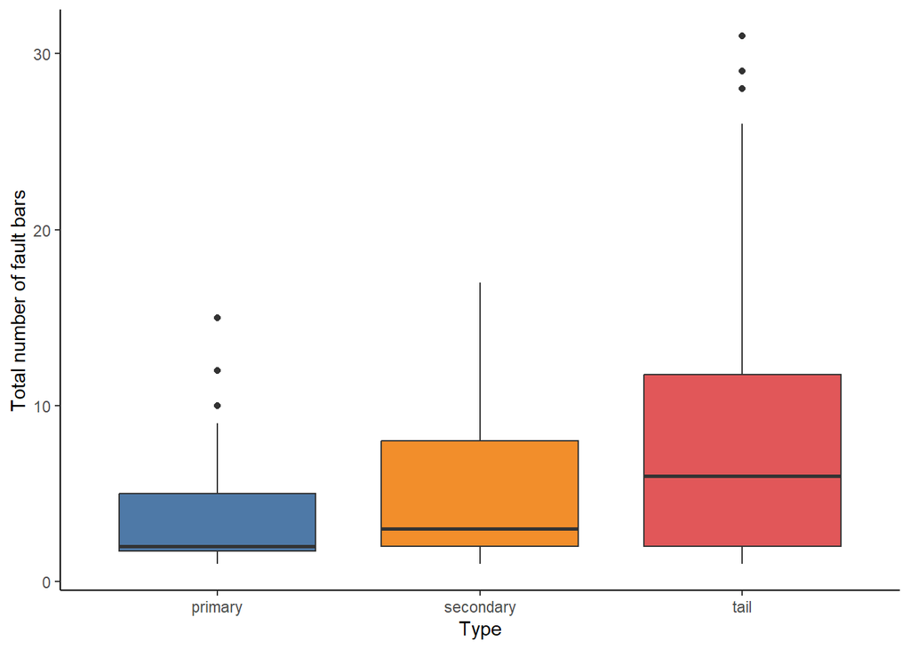

```r
fb.nozero.df <- fb.df %>% filter(TotalBars>0)
ggplot(data = fb.nozero.df, aes(x=Type, y=TotalBars))+
  geom_boxplot(fill = palette.colors(n = 3, palette = "Tableau 10"))+
  ylab("Total number of fault bars")
```

### Number of light fault bars (>0) per feather type

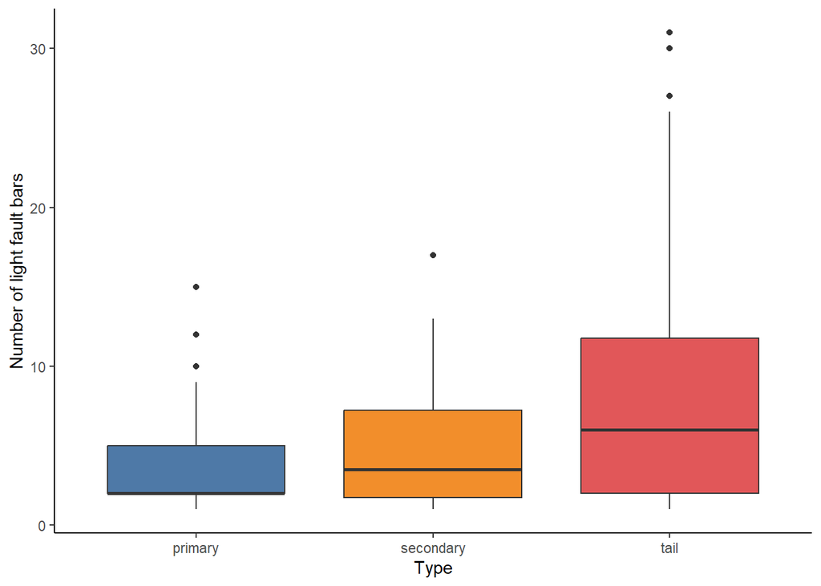

```r
fb.light.nozero.df <- fb.df %>% filter(LightBars>0)
ggplot(data = fb.light.nozero.df, aes(x=Type, y=LightBars))+
  geom_boxplot(fill = palette.colors(n = 3, palette = "Tableau 10"))+
  ylab("Number of light fault bars")
```

### Number of strong fault bars (>0) per feather type

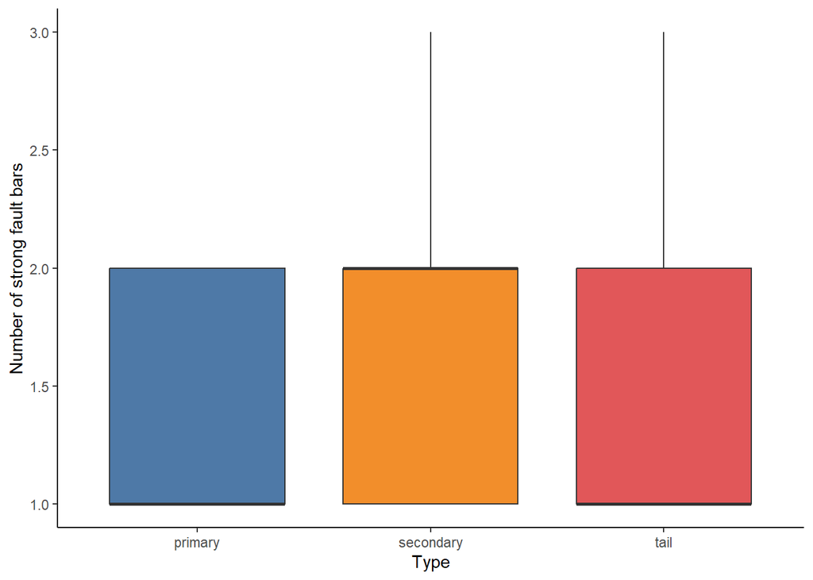

```r
fb.strong.nozero.df <- fb.df %>% filter(StrongBars>0)
ggplot(data = fb.strong.nozero.df, aes(x=Type, y=StrongBars))+
  geom_boxplot(fill = palette.colors(n = 3, palette = "Tableau 10"))+
  ylab("Number of strong fault bars")
```

## MODELING TOTAL FAULT BARS

### Poisson model for total number of fault bars

```r
total.poisson.mdl <- glmmTMB(data = fb.df, TotalBars ~ Habitat, family = "poisson")
```

### Zero inflation test for total.poisson.mdl

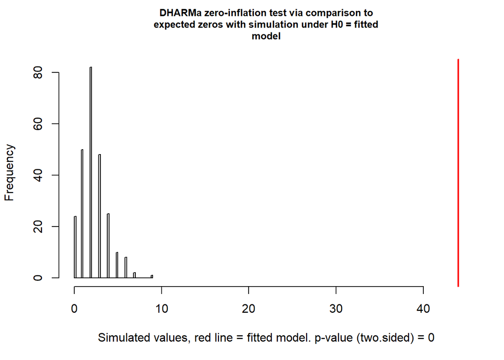

```
##
##  DHARMa zero-inflation test via comparison to expected zeros with
##  simulation under H0 = fitted model
##
## data:  simulationOutput
## ratioObsSim = 18.998, p-value < 2.2e-16
## alternative hypothesis: two.sided
```

```r
total.res.sim <- simulateResiduals(total.poisson.mdl)
testZeroInflation(total.res.sim)
```

### Overdispersion test for total.poisson.mdl

```r
testOverdispersion(total.res.sim)
```

```
## testOverdispersion is deprecated, switch your code to using the testDispersion function
```

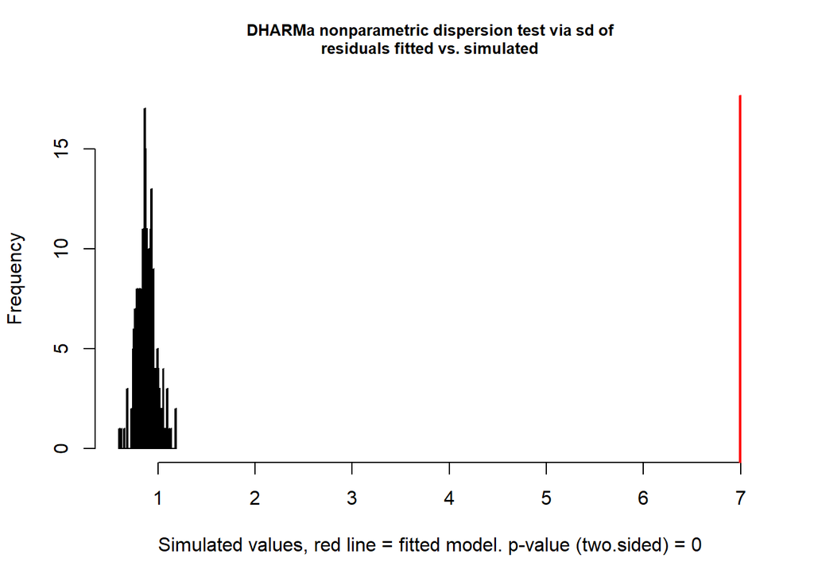

```
##
##  DHARMa nonparametric dispersion test via sd of residuals fitted vs.
##  simulated
##
## data:  simulationOutput
## dispersion = 7.918, p-value < 2.2e-16
## alternative hypothesis: two.sided
```

### Total fault bar zero inflated poisson model

```r
total.ZIP.mdl <- glmmTMB(data = fb.df, TotalBars ~ Habitat, ziformula = ~1, family = "poisson")
```

### Total fault bar model AIC comparison

```r
total.NB1.mdl <- update(total.ZIP.mdl, family = nbinom1)
total.NB2.mdl <- update(total.ZIP.mdl, family = nbinom2)
AICtab(total.poisson.mdl, total.ZIP.mdl, total.NB1.mdl, total.NB2.mdl)
```

```
##                   dAIC  df
## total.NB2.mdl       0.0 4
## total.NB1.mdl       0.5 4
## total.ZIP.mdl     394.8 3
## total.poisson.mdl 644.9 2
```

### Best fit total fault bar model

As per AIC comparison, the negative binomial 2 model provides the best fit.

```r
summary(total.NB2.mdl)
```

```
##  Family: nbinom2  ( log )
## Formula:          TotalBars ~ Habitat
## Zero inflation:             ~1
## Data: fb.df
##
##      AIC      BIC   logLik deviance df.resid
##    937.9    950.6   -464.9    929.9      175
##
##
## Dispersion parameter for nbinom2 family (): 0.676
##
## Conditional model:
##              Estimate Std. Error z value Pr(>|z|)
## (Intercept)    1.6896     0.1352  12.497   <2e-16 ***
## Habitaturban  -0.3469     0.1951  -1.778   0.0754 .
## ---
## Signif. codes:  0 '***' 0.001 '**' 0.01 '*' 0.05 '.' 0.1 ' ' 1
##
## Zero-inflation model:
##             Estimate Std. Error z value Pr(>|z|)
## (Intercept)   -18.56    4214.38  -0.004    0.996
```

### Outlier test for total.nb2.mdl

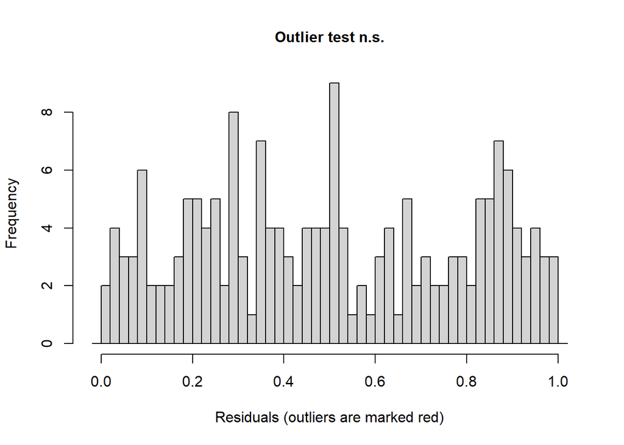

```
##
##  DHARMa bootstrapped outlier test
##
## data:  total.nb2.res.sim
## outliers at both margin(s) = 0, observations = 179, p-value = 1
## alternative hypothesis: greater
##  percent confidence interval:
##  0.00000000 0.01675978
## sample estimates:
## outlier frequency (expected: 0.00581005586592179 )
##                                                  0
```

```r
total.nb2.res.sim <- simulateResiduals(total.NB2.mdl)
testOutliers(total.nb2.res.sim, alternative = "greater")
```

### Total fault bar density plot

This plot shows the frequency of total fault bar numbers per feather in the urban and rural populations. Dotted lines are the urban and rural means.

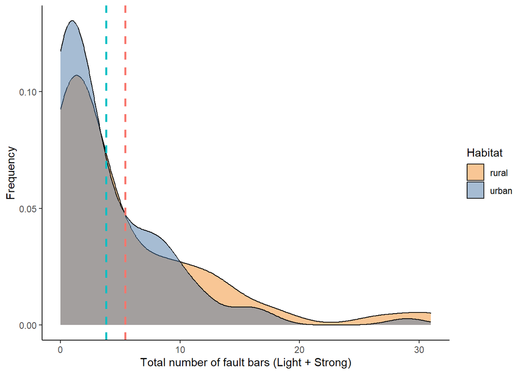

```r
TotHabitat <- c("Urban", "Rural")
TotMeans <- c(mean(fb.df$TotalBars[fb.df$Habitat=="urban"]), mean(fb.df$TotalBars[fb.df$Habitat=="rural"]))
TotHabitatMeans <- data.frame(TotHabitat,TotMeans)

TotalBarDensity.plot <- ggplot(fb.df, aes(x=TotalBars, fill = Habitat))+
  geom_density(alpha = 0.5)+
  geom_vline(data = TotHabitatMeans, aes(xintercept = TotMeans, color = TotHabitat),
             linetype="dashed",
             size = 1,
             show.legend = FALSE)+
  scale_fill_manual(values = c("#F28E2B", "#4E79A7"))+
  ylab("Frequency")+
  xlab("Total number of fault bars (Light + Strong)")
TotalBarDensity.plot
```

## MODELING LIGHT FAULT BARS

### Light fault bar poisson model

```r
light.poisson.mdl <- glmmTMB(data = fb.df, LightBars ~ Habitat, family = "poisson")
summary(light.poisson.mdl)
```

```
##  Family: poisson  ( log )
## Formula:          LightBars ~ Habitat
## Data: fb.df
##
##      AIC      BIC   logLik deviance df.resid
##   1557.7   1564.1   -776.9   1553.7      177
##
##
## Conditional model:
##              Estimate Std. Error z value Pr(>|z|)
## (Intercept)   1.66501    0.04560   36.52  < 2e-16 ***
## Habitaturban -0.39295    0.07255   -5.42 6.09e-08 ***
## ---
## Signif. codes:  0 '***' 0.001 '**' 0.01 '*' 0.05 '.' 0.1 ' ' 1
```

### Zero inflation test for light.poisson.mdl

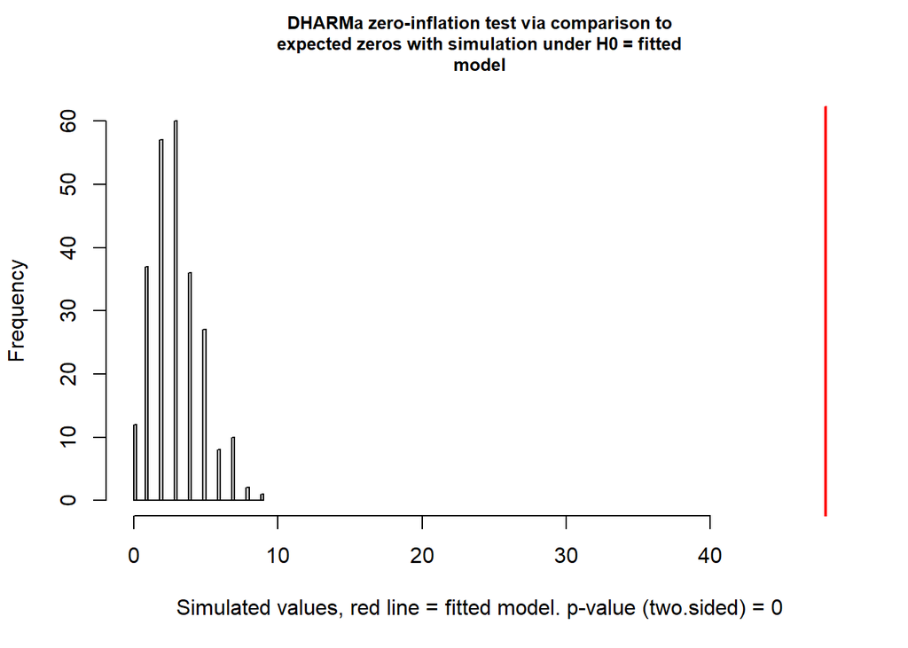

```
##
##  DHARMa zero-inflation test via comparison to expected zeros with
##  simulation under H0 = fitted model
##
## data:  simulationOutput
## ratioObsSim = 15.936, p-value < 2.2e-16
## alternative hypothesis: two.sided
```

```r
light.res.sim <- simulateResiduals(light.poisson.mdl)
testZeroInflation(light.res.sim)
```

### Overdispersion test for light.poisson.mdl

```r
testOverdispersion(light.res.sim)
```

```
## testOverdispersion is deprecated, switch your code to using the testDispersion function
```

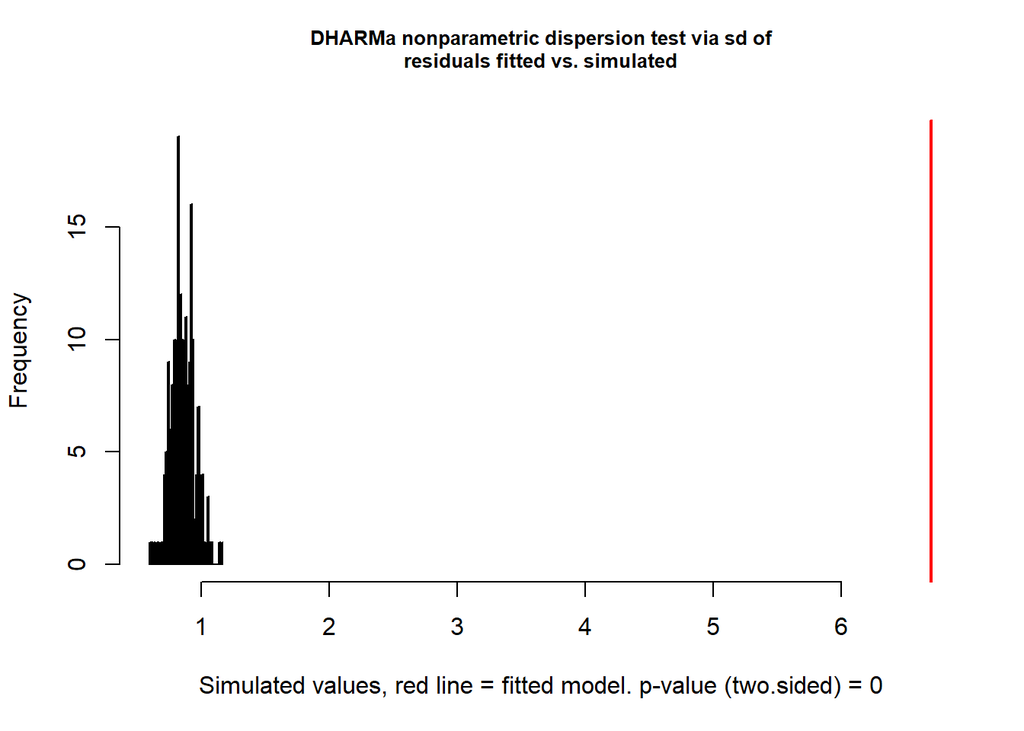

```
##
##  DHARMa nonparametric dispersion test via sd of residuals fitted vs.
##  simulated
##
## data:  simulationOutput
## dispersion = 7.774, p-value < 2.2e-16
## alternative hypothesis: two.sided
```

### Light fault bar zero inflated poisson model

```r
light.ZIP.mdl <- glmmTMB(data = fb.df, LightBars ~ Habitat, ziformula = ~1, family = "poisson")
```

### Light fault bar model AIC comparison

```r
light.NB1.mdl <- update(light.ZIP.mdl, family = nbinom1)
light.NB2.mdl <- update(light.ZIP.mdl, family = nbinom2)
AICtab(light.poisson.mdl, light.ZIP.mdl, light.NB1.mdl, light.NB2.mdl)
```

```
##                   dAIC  df
## light.NB1.mdl       0.0 4
## light.NB2.mdl       0.9 4
## light.ZIP.mdl     376.5 3
## light.poisson.mdl 638.8 2
```

### Best fit light model

As per AIC comparison, negative binomial 1 model provides the best fit

```r
summary(light.NB1.mdl)
```

```
##  Family: nbinom1  ( log )
## Formula:          LightBars ~ Habitat
## Zero inflation:             ~1
## Data: fb.df
##
##      AIC      BIC   logLik deviance df.resid
##    918.9    931.6   -455.4    910.9      175
##
##
## Dispersion parameter for nbinom1 family (): 7.05
##
## Conditional model:
##              Estimate Std. Error z value Pr(>|z|)
## (Intercept)    1.6468     0.1202  13.699   <2e-16 ***
## Habitaturban  -0.3475     0.1621  -2.144    0.032 *
## ---
## Signif. codes:  0 '***' 0.001 '**' 0.01 '*' 0.05 '.' 0.1 ' ' 1
##
## Zero-inflation model:
##             Estimate Std. Error z value Pr(>|z|)
## (Intercept)   -19.06    4759.94  -0.004    0.997
```

### Overdispersion test for light.NB1.mdl

```r
light.NB1.res.sim <- simulateResiduals(light.NB1.mdl)
testOverdispersion(light.NB1.res.sim)
```

```
## testOverdispersion is deprecated, switch your code to using the testDispersion function
```

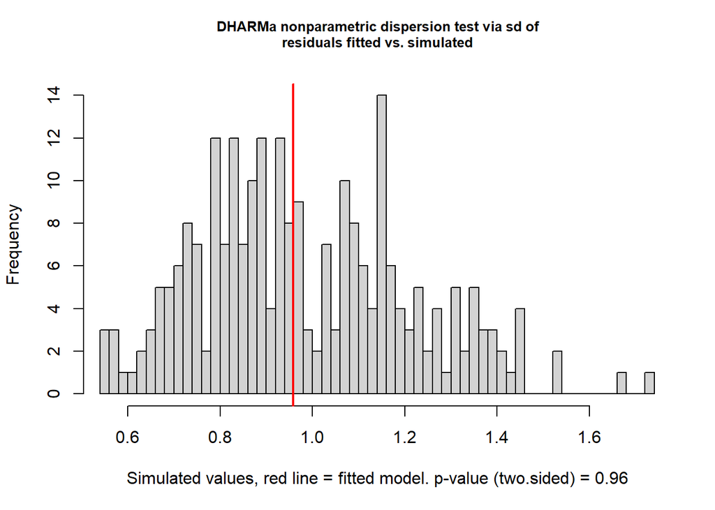

```
##
##  DHARMa nonparametric dispersion test via sd of residuals fitted vs.
##  simulated
##
## data:  simulationOutput
## dispersion = 0.97372, p-value = 0.96
## alternative hypothesis: two.sided
```

### Outlier test for light.NB1.mdl

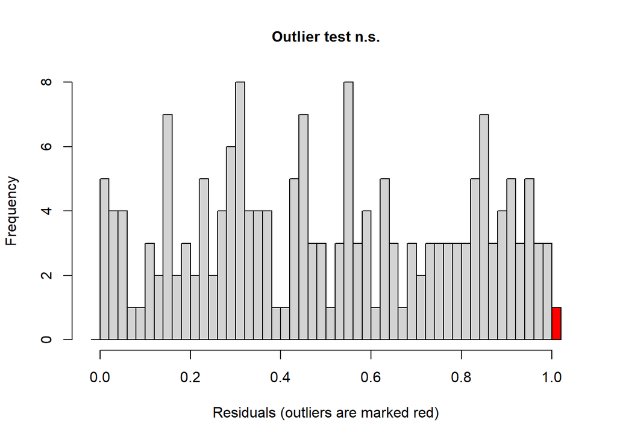

```
##
##  DHARMa bootstrapped outlier test
##
## data:  light.NB1.mdl
## outliers at both margin(s) = 1, observations = 179, p-value = 0.71
## alternative hypothesis: greater
##  percent confidence interval:
##  0.00000000 0.01969274
## sample estimates:
## outlier frequency (expected: 0.0064804469273743 )
##                                       0.005586592
```

```r
testOutliers(light.NB1.mdl, alternative = "greater")
```

### Light fault bar density plot

This plot shows the frequency of light fault bar numbers in the urban and rural populations. Dotted lines are the urban and rural means.

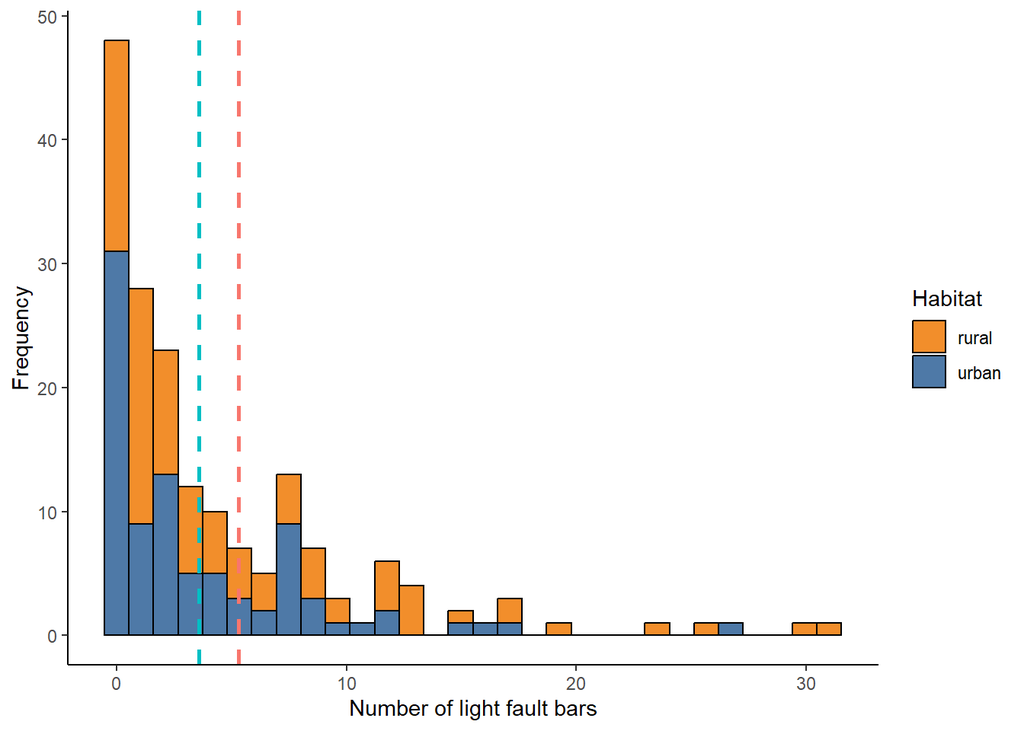

```r
LightHabitat <- c("Urban", "Rural")
LightMeans <- c(mean(fb.df$LightBars[fb.df$Habitat=="urban"]),mean(fb.df$LightBars[fb.df$Habitat=="rural"]))
LightHabitatMeans <- data.frame(LightHabitat,LightMeans)

LightBarDensity.plot <- ggplot(fb.df, aes(x=LightBars, fill = Habitat))+
  geom_histogram(color = "black")+
  geom_vline(data = LightHabitatMeans, aes(xintercept = LightMeans, color = LightHabitat),
             linetype="dashed",
             size = 1,
             show.legend = FALSE)+
  scale_fill_manual(values = c("#F28E2B", "#4E79A7"))+
  ylab("Frequency")+
  xlab("Number of light fault bars")

LightBarDensity.plot
```

## MODELING STRONG FAULT BARS

### Strong fault bar poisson model

```r
strong.poisson.mdl <- glmmTMB(data = fb.df, StrongBars ~ Habitat, family = "poisson")
summary(strong.poisson.mdl)
```

```
##  Family: poisson  ( log )
## Formula:          StrongBars ~ Habitat
## Data: fb.df
##
##      AIC      BIC   logLik deviance df.resid
##    204.8    211.2   -100.4    200.8      177
##
##
## Conditional model:
##              Estimate Std. Error z value Pr(>|z|)
## (Intercept)   -2.0260     0.2887  -7.018 2.25e-12 ***
## Habitaturban   0.6841     0.3561   1.921   0.0547 .
## ---
## Signif. codes:  0 '***' 0.001 '**' 0.01 '*' 0.05 '.' 0.1 ' ' 1
```

### Zero inflation test for strong.poisson.mdl

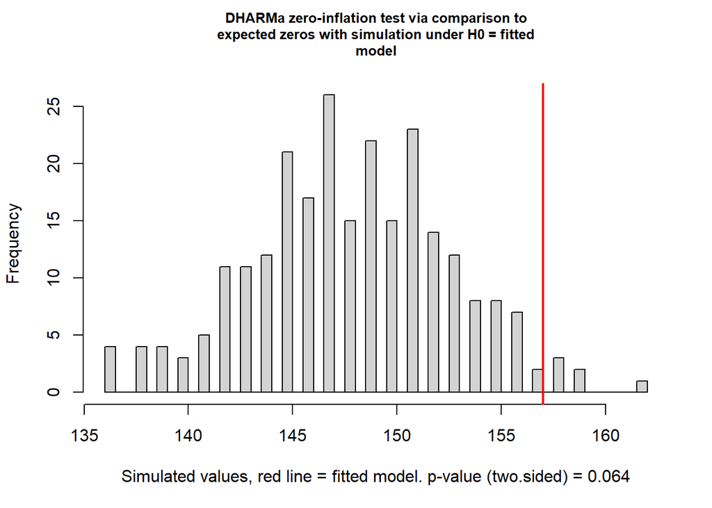

```
##
##  DHARMa zero-inflation test via comparison to expected zeros with
##  simulation under H0 = fitted model
##
## data:  simulationOutput
## ratioObsSim = 1.0606, p-value = 0.064
## alternative hypothesis: two.sided
```

```r
strong.res.sim <- simulateResiduals(strong.poisson.mdl)
testZeroInflation(strong.res.sim)
```

### Overdispersion test for strong.poisson.mdl

```r
testOverdispersion(strong.res.sim)
```

```
## testOverdispersion is deprecated, switch your code to using the testDispersion function
```

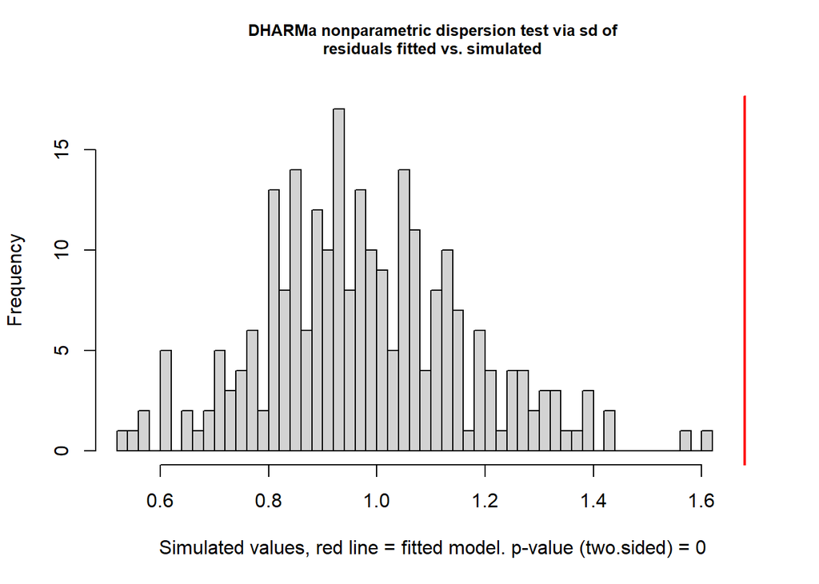

```
##
##  DHARMa nonparametric dispersion test via sd of residuals fitted vs.
##  simulated
##
## data:  simulationOutput
## dispersion = 1.7154, p-value < 2.2e-16
## alternative hypothesis: two.sided
```

### Strong fault bar zero inflated poisson model

```r
strong.ZIP.mdl <- glmmTMB(data = fb.df, StrongBars ~ Habitat, ziformula = ~1, family = "poisson")
```

```r
strong.NB1.mdl <- glmmTMB(data = fb.df, StrongBars ~ Habitat, ziformula = ~1, family = "nbinom1")
```

```r
strong.NB2.mdl <- glmmTMB(data = fb.df, StrongBars ~ Habitat, ziformula = ~1, family = "nbinom2")
```

### Strong fault bar model AIC comparison

```r
AICtab(strong.poisson.mdl, strong.ZIP.mdl, strong.NB1.mdl)
```

```
##                    dAIC df
## strong.ZIP.mdl      0.0 3
## strong.NB1.mdl      1.7 4
## strong.poisson.mdl 21.9 2
```

### Best fit strong model

AIC comparison says that ZIP model fits best, but the zero inflation test is non significant. There is not a strong difference between the ZIP and NB1 model, so I’m including the NB1 model result. The result is non significant but shows a trend that’s opposite of the light model; there are marginally MORE strong bars in urban habitats.

```r
summary(strong.NB1.mdl)
```

```
##  Family: nbinom1  ( log )
## Formula:          StrongBars ~ Habitat
## Zero inflation:              ~1
## Data: fb.df
##
##      AIC      BIC   logLik deviance df.resid
##    184.6    197.4    -88.3    176.6      175
##
##
## Dispersion parameter for nbinom1 family (): 0.409
##
## Conditional model:
##              Estimate Std. Error z value Pr(>|z|)
## (Intercept)   -0.9437     1.0245  -0.921    0.357
## Habitaturban   0.7798     0.5782   1.349    0.177
##
## Zero-inflation model:
##             Estimate Std. Error z value Pr(>|z|)
## (Intercept)   0.7779     1.1371   0.684    0.494
```

```r
strong.ZIP.res.sim <- simulateResiduals(strong.ZIP.mdl)
testOverdispersion(strong.ZIP.res.sim)
```

```
## testOverdispersion is deprecated, switch your code to using the testDispersion function
```

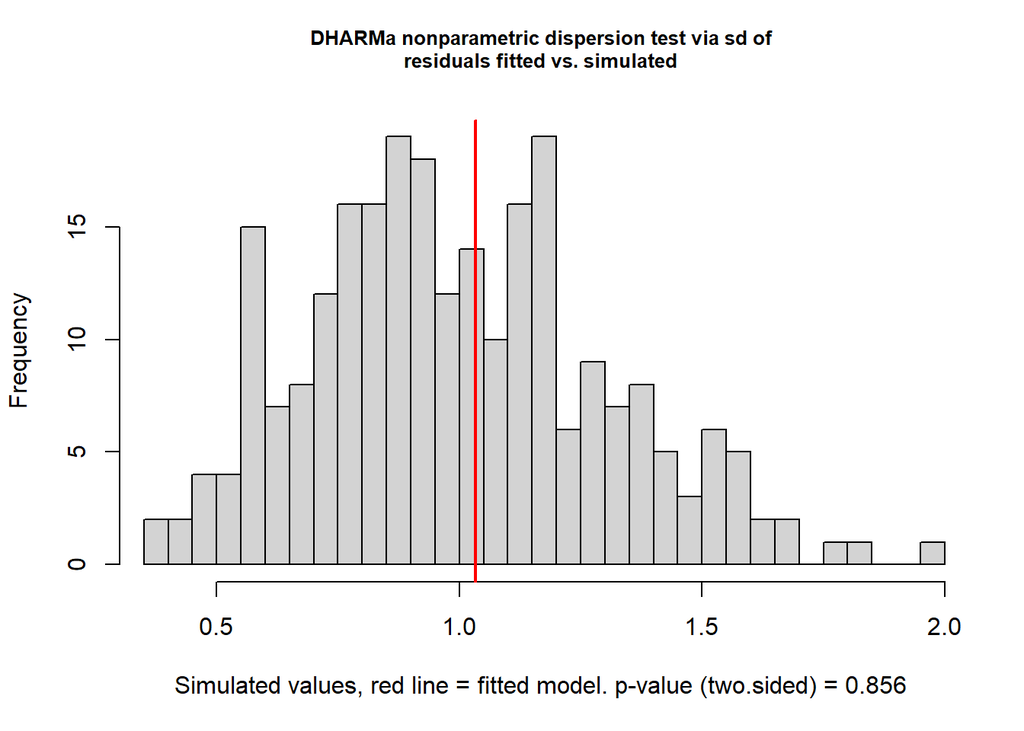

```
##
##  DHARMa nonparametric dispersion test via sd of residuals fitted vs.
##  simulated
##
## data:  simulationOutput
## dispersion = 1.0372, p-value = 0.856
## alternative hypothesis: two.sided
```

### Outlier test for strong.NB1.mdl

The NB1 model has no outliers

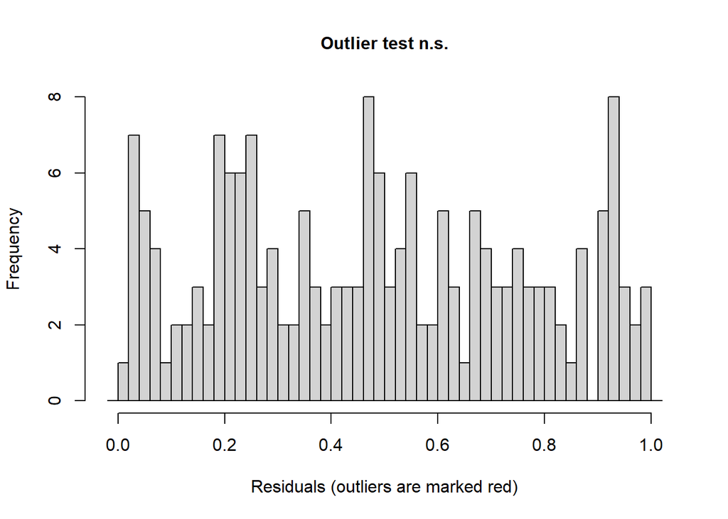

```
##
##  DHARMa bootstrapped outlier test
##
## data:  strong.NB1.mdl
## outliers at both margin(s) = 0, observations = 179, p-value = 1
## alternative hypothesis: greater
##  percent confidence interval:
##  0.00000000 0.01675978
## sample estimates:
## outlier frequency (expected: 0.00385474860335196 )
##                                                  0
```

```r
testOutliers(strong.NB1.mdl, alternative = "greater")
```

### Strong fault bar density plot

This plot shows the frequency of strong fault bar numbers in the urban and rural populations. Dotted lines are the urban and rural means.

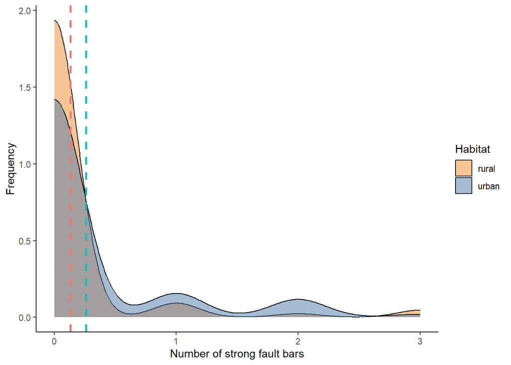

```r
StrongHabitat <- c("Urban", "Rural")
StrongMeans <- c(mean(fb.df$StrongBars[fb.df$Habitat=="urban"]),mean(fb.df$StrongBars[fb.df$Habitat=="rural"]))
StrongHabitatMeans <- data.frame(StrongHabitat,StrongMeans)

StrongBarDensity.plot <- ggplot(fb.df, aes(x=StrongBars, fill = Habitat))+
  geom_density(alpha=0.5)+
  geom_vline(data = StrongHabitatMeans, aes(xintercept = StrongMeans, color = StrongHabitat),
             linetype="dashed",
             size = 1,
             show.legend = FALSE)+
  scale_fill_manual(values = c("#F28E2B", "#4E79A7"))+
  ylab("Frequency")+
  xlab("Number of strong fault bars")

StrongBarDensity.plot
```

## MODELING TAIL FAULT BARS

### Tail feather subset

```r
fb.tail.df <- subset(fb.df, Type == "tail")
```

### Total tail fault bar poisson model

```r
tot.tail.poisson.mdl <- glmmTMB(data = fb.tail.df, TotalBars ~ Habitat, family = "poisson")
```

### Zero inflation test for tot.tail.poisson.mdl

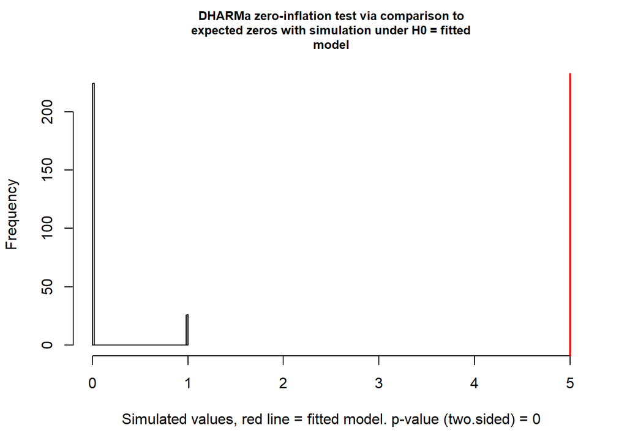

```
##
##  DHARMa zero-inflation test via comparison to expected zeros with
##  simulation under H0 = fitted model
##
## data:  simulationOutput
## ratioObsSim = 48.077, p-value < 2.2e-16
## alternative hypothesis: two.sided
```

```r
tot.tail.res.sim <- simulateResiduals(tot.tail.poisson.mdl)
testZeroInflation(tot.tail.res.sim)
```

### Overdispersion test for tot.tail.poisson.mdl

```r
testOverdispersion(tot.tail.res.sim)
```

```
## testOverdispersion is deprecated, switch your code to using the testDispersion function
```

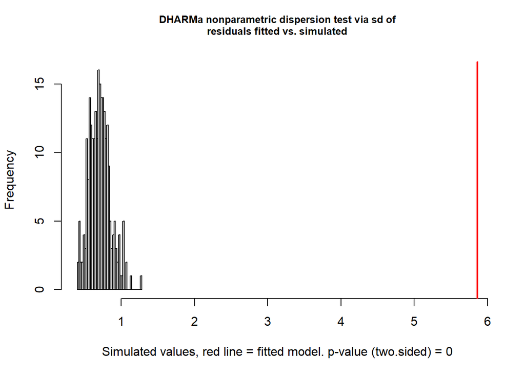

```
##
##  DHARMa nonparametric dispersion test via sd of residuals fitted vs.
##  simulated
##
## data:  simulationOutput
## dispersion = 8.3025, p-value < 2.2e-16
## alternative hypothesis: two.sided
```

### Total tail fault bar zero inflated poisson model

```r
tot.tail.ZIP.mdl <- glmmTMB(data = fb.tail.df, TotalBars ~ Habitat, ziformula = ~1, family = "poisson")
```

### Total tail fault bar model AIC comparison

```r
tot.tail.NB1.mdl <- update(tot.tail.ZIP.mdl, family = nbinom1)
tot.tail.NB2.mdl <- update(tot.tail.ZIP.mdl, family = nbinom2)
AICtab(tot.tail.ZIP.mdl, tot.tail.NB1.mdl, tot.tail.NB2.mdl)
```

```
##                  dAIC  df
## tot.tail.NB2.mdl   0.0 4
## tot.tail.NB1.mdl   1.4 4
## tot.tail.ZIP.mdl 205.8 3
```

### Best fit tot.tail model

As per AIC comparison, negative binomial 2 model provides the best fit

```r
summary(tot.tail.NB2.mdl)
```

```
##  Family: nbinom2  ( log )
## Formula:          TotalBars ~ Habitat
## Zero inflation:             ~1
## Data: fb.tail.df
##
##      AIC      BIC   logLik deviance df.resid
##    373.7    382.0   -182.9    365.7       55
##
##
## Dispersion parameter for nbinom2 family (): 1.08
##
## Conditional model:
##              Estimate Std. Error z value Pr(>|z|)
## (Intercept)    2.2618     0.1854  12.201   <2e-16 ***
## Habitaturban  -0.4586     0.2683  -1.709   0.0874 .
## ---
## Signif. codes:  0 '***' 0.001 '**' 0.01 '*' 0.05 '.' 0.1 ' ' 1
##
## Zero-inflation model:
##             Estimate Std. Error z value Pr(>|z|)
## (Intercept)   -20.67    8800.25  -0.002    0.998
```

### Light tail fault bar poisson model

```r
light.tail.poisson.mdl <- glmmTMB(data = fb.tail.df, LightBars ~ Habitat, family = "poisson")
```

### Zero inflation test for light.tail.poisson.mdl

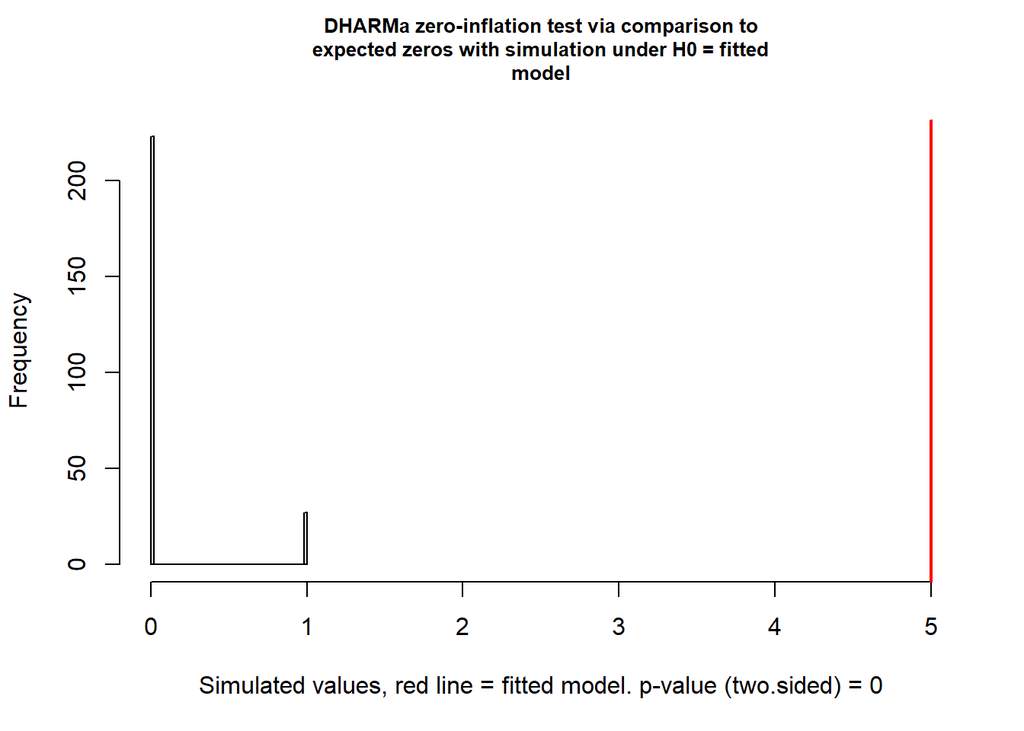

```
##
##  DHARMa zero-inflation test via comparison to expected zeros with
##  simulation under H0 = fitted model
##
## data:  simulationOutput
## ratioObsSim = 46.296, p-value < 2.2e-16
## alternative hypothesis: two.sided
```

```r
light.tail.res.sim <- simulateResiduals(light.tail.poisson.mdl)
testZeroInflation(light.tail.res.sim)
```

### Overdispersion test for light.tail.poisson.mdl

```r
testOverdispersion(light.tail.res.sim)
```

```
## testOverdispersion is deprecated, switch your code to using the testDispersion function
```

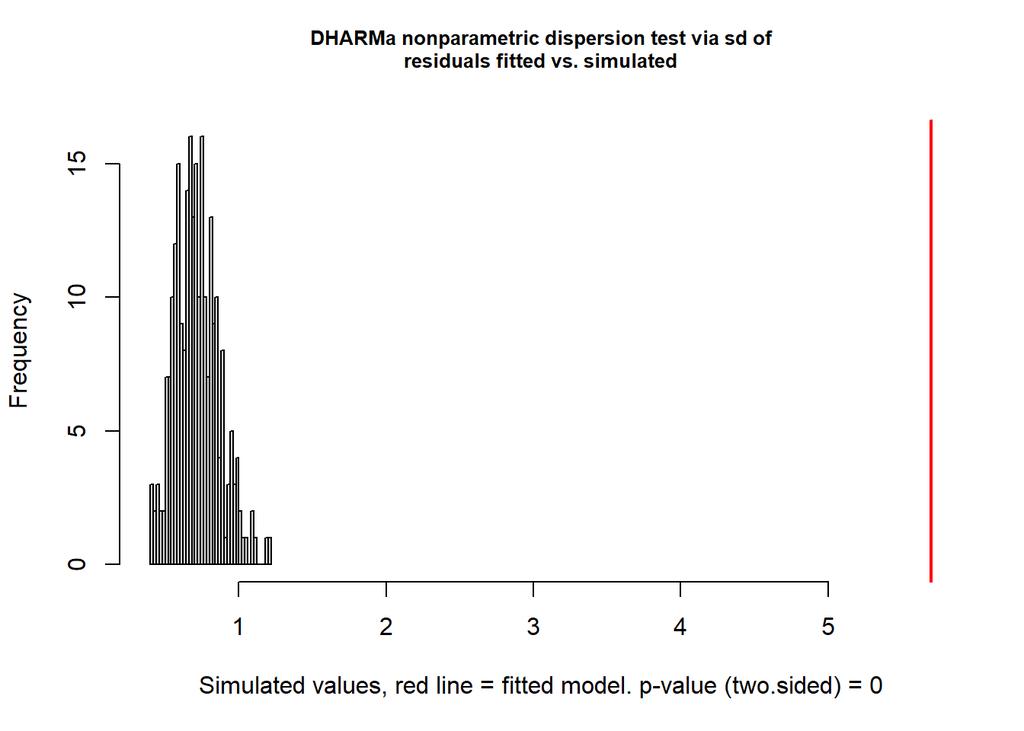

```
##
##  DHARMa nonparametric dispersion test via sd of residuals fitted vs.
##  simulated
##
## data:  simulationOutput
## dispersion = 7.9805, p-value < 2.2e-16
## alternative hypothesis: two.sided
```

### Light tail fault bar zero inflated poisson model

```r
light.tail.ZIP.mdl <- glmmTMB(data = fb.tail.df, LightBars ~ Habitat, ziformula = ~1, family = "poisson")
```

### Light tail fault bar model AIC comparison

```r
light.tail.NB1.mdl <- update(light.tail.ZIP.mdl, family = nbinom1)
light.tail.NB2.mdl <- update(light.tail.ZIP.mdl, family = nbinom2)
AICtab(light.tail.ZIP.mdl, light.tail.NB1.mdl, light.tail.NB2.mdl)
```

```
##                    dAIC  df
## light.tail.NB2.mdl   0.0 4
## light.tail.NB1.mdl   1.1 4
## light.tail.ZIP.mdl 198.9 3
```

### Best fit light.tail model

As per AIC comparison, negative binomial 2 model provides the best fit

```r
summary(light.tail.NB2.mdl)
```

```
##  Family: nbinom2  ( log )
## Formula:          LightBars ~ Habitat
## Zero inflation:             ~1
## Data: fb.tail.df
##
##      AIC      BIC   logLik deviance df.resid
##    369.9    378.2   -180.9    361.9       55
##
##
## Dispersion parameter for nbinom2 family (): 1.06
##
## Conditional model:
##              Estimate Std. Error z value Pr(>|z|)
## (Intercept)    2.2264     0.1869  11.913   <2e-16 ***
## Habitaturban  -0.4579     0.2706  -1.692   0.0906 .
## ---
## Signif. codes:  0 '***' 0.001 '**' 0.01 '*' 0.05 '.' 0.1 ' ' 1
##
## Zero-inflation model:
##             Estimate Std. Error z value Pr(>|z|)
## (Intercept)   -20.57    7684.00  -0.003    0.998
```

## MODELING SECONDARY FAULT BARS

### Secondary feather subset

```r
fb.sec.df <- subset(fb.df, Type == "secondary")
```

### Total secondary fault bar poisson model

```r
tot.sec.poisson.mdl <- glmmTMB(data = fb.sec.df, TotalBars ~ Habitat, family = "poisson")
```

### Zero inflation test for tot.sec.poisson.mdl

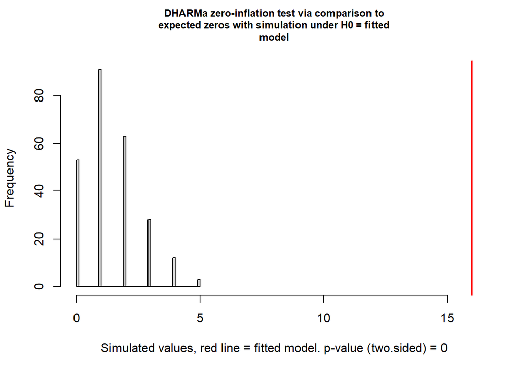

```
##
##  DHARMa zero-inflation test via comparison to expected zeros with
##  simulation under H0 = fitted model
##
## data:  simulationOutput
## ratioObsSim = 10.989, p-value < 2.2e-16
## alternative hypothesis: two.sided
```

```r
tot.sec.res.sim <- simulateResiduals(tot.sec.poisson.mdl)
testZeroInflation(tot.sec.res.sim)
```

### Overdispersion test for tot.sec.poisson.mdl

```r
testOverdispersion(tot.sec.res.sim)
```

```
## testOverdispersion is deprecated, switch your code to using the testDispersion function
```

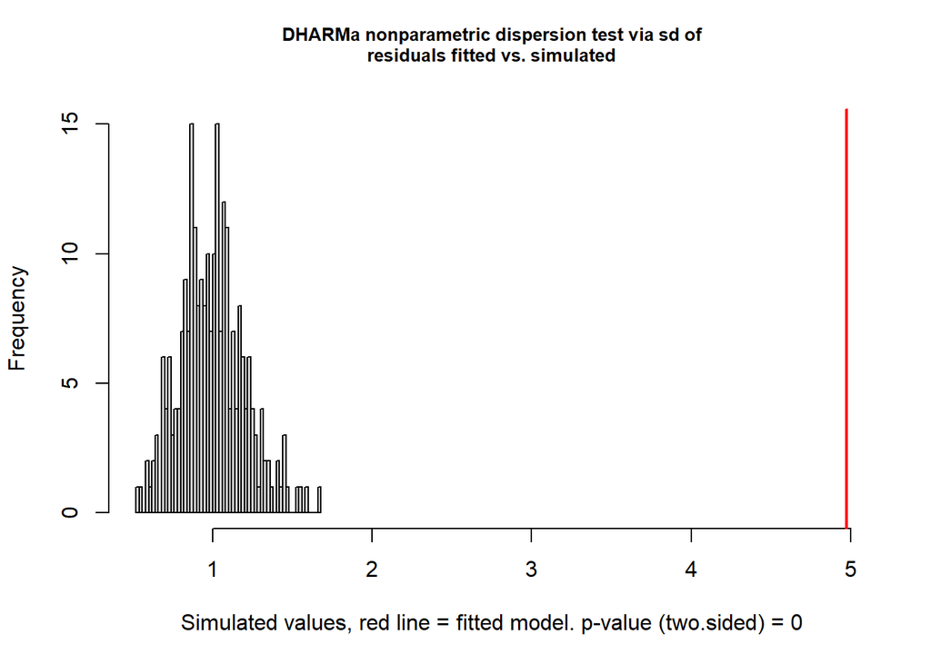

```
##
##  DHARMa nonparametric dispersion test via sd of residuals fitted vs.
##  simulated
##
## data:  simulationOutput
## dispersion = 4.9766, p-value < 2.2e-16
## alternative hypothesis: two.sided
```

```r
tot.sec.ZIP.mdl <- glmmTMB(data = fb.sec.df, LightBars ~ Habitat, ziformula = ~1, family = "poisson")
```

```r
tot.sec.NB1.mdl <- update(tot.sec.ZIP.mdl, family = nbinom1)
tot.sec.NB2.mdl <- update(tot.sec.ZIP.mdl, family = nbinom2)
AICtab(tot.sec.poisson.mdl, tot.sec.ZIP.mdl, tot.sec.NB1.mdl, tot.sec.NB2.mdl)
```

```
##                     dAIC  df
## tot.sec.NB1.mdl       0.0 4
## tot.sec.NB2.mdl       1.0 4
## tot.sec.ZIP.mdl      59.4 3
## tot.sec.poisson.mdl 133.4 2
```

### Best fit tot.sec model

As per AIC comparison, negative binomial 1 model provides the best fit. Result is non significant

```r
summary(tot.sec.NB1.mdl)
```

```
##  Family: nbinom1  ( log )
## Formula:          LightBars ~ Habitat
## Zero inflation:             ~1
## Data: fb.sec.df
##
##      AIC      BIC   logLik deviance df.resid
##    296.8    305.2   -144.4    288.8       57
##
##
## Dispersion parameter for nbinom1 family ():  4.8
##
## Conditional model:
##              Estimate Std. Error z value Pr(>|z|)
## (Intercept)    1.3894     0.1989   6.985 2.85e-12 ***
## Habitaturban  -0.2953     0.2784  -1.061    0.289
## ---
## Signif. codes:  0 '***' 0.001 '**' 0.01 '*' 0.05 '.' 0.1 ' ' 1
##
## Zero-inflation model:
##             Estimate Std. Error z value Pr(>|z|)
## (Intercept)   -18.83    8429.79  -0.002    0.998
```

## MODELING PRIMARY FAULT BARS

### Primary feather subset

```r
fb.prim.df <- subset(fb.df, Type == "primary")
```

### Total primary fault bar poisson model

```r
tot.prim.poisson.mdl <- glmmTMB(data = fb.prim.df, TotalBars ~ Habitat, family = "poisson")
```

### Zero inflation test for tot.prim.poisson.mdl

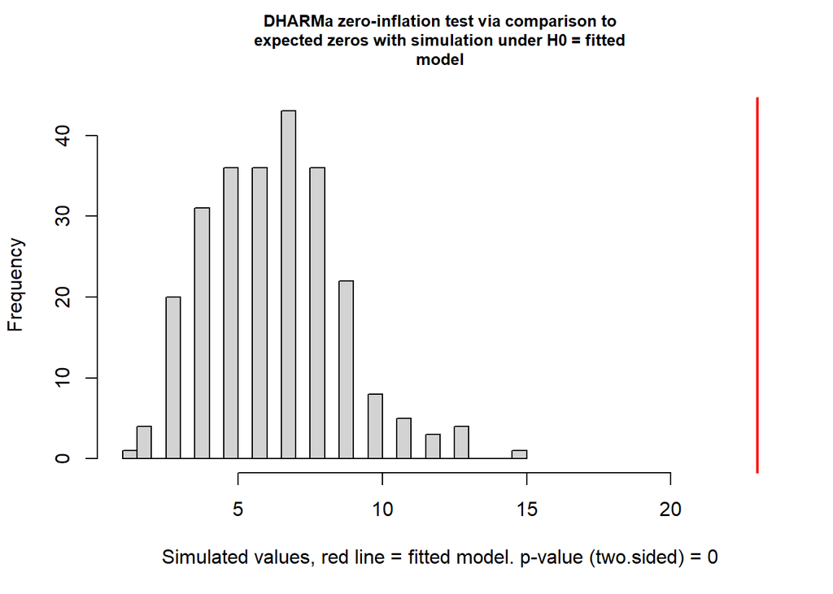

```
##
##  DHARMa zero-inflation test via comparison to expected zeros with
##  simulation under H0 = fitted model
##
## data:  simulationOutput
## ratioObsSim = 3.5626, p-value < 2.2e-16
## alternative hypothesis: two.sided
```

```r
tot.prim.res.sim <- simulateResiduals(tot.prim.poisson.mdl)
testZeroInflation(tot.prim.res.sim)
```

### Overdispersion test for tot.prim.poisson.mdl

```r
testOverdispersion(tot.prim.res.sim)
```

```
## testOverdispersion is deprecated, switch your code to using the testDispersion function
```

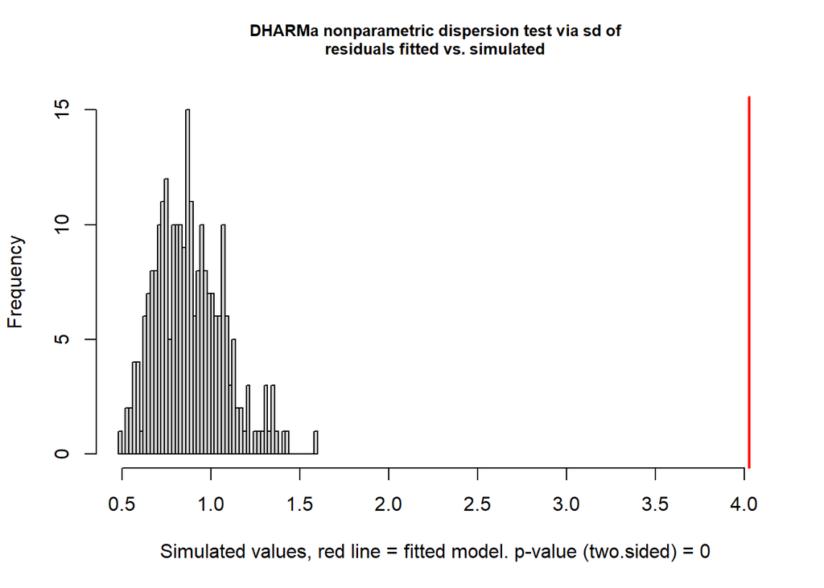

```
##
##  DHARMa nonparametric dispersion test via sd of residuals fitted vs.
##  simulated
##
## data:  simulationOutput
## dispersion = 4.5561, p-value < 2.2e-16
## alternative hypothesis: two.sided
```

```r
tot.prim.ZIP.mdl <- glmmTMB(data = fb.prim.df, LightBars ~ Habitat, ziformula = ~1, family = "poisson")
```

### Total prim fault bar model AIC comparison

```r
tot.prim.NB1.mdl <- update(tot.prim.ZIP.mdl, family = nbinom1)
tot.prim.NB2.mdl <- update(tot.prim.ZIP.mdl, family = nbinom2)
AICtab(tot.prim.poisson.mdl, tot.prim.ZIP.mdl, tot.prim.NB1.mdl, tot.prim.NB2.mdl)
```

```
##                      dAIC df
## tot.prim.NB1.mdl      0.0 4
## tot.prim.NB2.mdl      0.9 4
## tot.prim.ZIP.mdl     33.6 3
## tot.prim.poisson.mdl 95.6 2
```

### Best fit tot.prim model

As per AIC comparison, negative binomial 1 model provides the best fit

```r
summary(tot.prim.NB1.mdl)
```

```
##  Family: nbinom1  ( log )
## Formula:          LightBars ~ Habitat
## Zero inflation:             ~1
## Data: fb.prim.df
##
##      AIC      BIC   logLik deviance df.resid
##    234.9    243.2   -113.5    226.9       55
##
##
## Dispersion parameter for nbinom1 family ():  4.4
##
## Conditional model:
##              Estimate Std. Error z value Pr(>|z|)
## (Intercept)    1.0531     0.2377   4.431 9.36e-06 ***
## Habitaturban  -0.5652     0.3373  -1.676   0.0937 .
## ---
## Signif. codes:  0 '***' 0.001 '**' 0.01 '*' 0.05 '.' 0.1 ' ' 1
##
## Zero-inflation model:
##             Estimate Std. Error z value Pr(>|z|)
## (Intercept)   -16.72    8606.08  -0.002    0.998
```